# Chapter 3: Working with `zoo` and `xts` Objects

# The `zoo` class

The **zoo** package provides a framework for working with regular and irregular time series data. It is comprised of two components:

- Data structure: a vector or matrix format
- Index vector: this stores the series observation’s corresponding index

Unlike the `ts` class, the index of the `zoo` class can store different date and time classes, such as `Date`, `POSIXct/lt`, `yearmon`, or `yearqtr`, as indices.

```r
library(TSstudio)
library(zoo)
data("EURO_Brent")

ts_info(EURO_Brent)
```

```
 The EURO_Brent series is a zoo object with 1 variable and 392 observations
 Frequency: monthly
 Start time: May 1987
 End time: Dec 2019
```

## The `zoo` class attributes

Pretty much the same as with `ts` objects.

## The index of the `zoo` object

```r
head(index(EURO_Brent))
```

```
[1] "May 1987" "Jun 1987" "Jul 1987" "Aug 1987" "Sep 1987" "Oct 1987"
```

`zoo` objects have their own `attributes()` and `class()` functions:

```r
class(index(EURO_Brent))
```

```
[1] "yearmon"
```

```r
attributes(index(EURO_Brent))
```

```
$class
[1] "yearmon"
```

## Working with date and time objects

The **zoo** package provides a set of utility functions for handling and preprocessing date and time objects. The package also comes with two types of `date` objects, `yearmon` and `yearqtr`, for indexing a monthly and quarterly series, respectively.

Let’s create a sequence of 12 dates, representing the beginning of each month in 2019, with the `seq.Date` function:

```r
monthly_dates <- seq.Date(from = as.Date("2019-01-01"), length.out = 12,
                          by = "month")

head(monthly_dates)
```

```
[1] "2019-01-01" "2019-02-01" "2019-03-01" "2019-04-01" "2019-05-01" "2019-06-01"
```

Next, we use the `as.yearmon()` function to convert the `monthly_dates` object to a `yearmon` object:

```r
monthly_yearmon <- as.yearmon(monthly_dates)
head(monthly_yearmon)
```

```
[1] "Jan 2019" "Feb 2019" "Mar 2019" "Apr 2019" "May 2019" "Jun 2019"
```

The `as.Date.ts()` function allows us to convert the time stamp of a `ts` object to a `Date` object when applicable.

```r
data(USgas)

head(time(USgas))
```

```
[1] 2000.000 2000.083 2000.167 2000.250 2000.333 2000.417
```

Now let’s look at the results of the `as.Date.ts()` function:

```r
head(as.Date.ts(USgas))
```

```
[1] "2000-01-01" "2000-02-01" "2000-03-01" "2000-04-01" "2000-05-01" "2000-06-01"
```

## Creating a `zoo` object

```r
head(vehicle_sales1)
```

```
Jan 0001 Jan 0002 Jan 0003 Jan 0004 Jan 0005 Jan 0006
   885.2    994.7   1243.6   1191.2   1203.2   1254.7
```

The `order.by` argument is used to set the `index` operator of the output object.

```r
head(vehicle_sales2)
```

```
1976-01-31 1976-02-29 1976-03-31 1976-04-30 1976-05-31 1976-06-30
     885.2      994.7     1243.6     1191.2     1203.2     1254.7
```

We can also use `as.zoo()` to convert series to `zoo` objects:

```r
ts_info(usgas_zoo)
```

```
 The usgas_zoo series is a zoo object with 1 variable and 238 observations
 Frequency: monthly
 Start time: Jan 2000
 End time: Oct 2019
```

## Working with multiple time series objects

We create a multivariate time series object by combining multiple columns:

```r
head(us_indicators_zoo)
```

```
           Vehicle Sales Unemployment Rate
1976-01-31         885.2               8.8
1976-02-29         994.7               8.7
1976-03-31        1243.6               8.1
1976-04-30        1191.2               7.4
1976-05-31        1203.2               6.8
1976-06-30        1254.7               8.0
```

# The xts class

the **xts** package provides the `xts` class and a set of functions and tools for preprocessing, manipulating, and visualizing time series data.

```r
ts_info(Michigan_CS)
```

```
 The Michigan_CS series is a xts object with 1 variable and 480 observations
 Frequency: monthly
 Start time: Jan 1980
 End time: Dec 2019
```

## The xts functionality

#### The periodicity function

```r
periodicity(Michigan_CS)
```

```
Monthly periodicity from Jan 1980 to Dec 2019
```

#### Manipulating the object index

```r
tclass(Michigan_CS)
```

```
[1] "yearmon"
```

We can convert eh object index class with `coverIndex`.

```r
tclass(Michigan_CS)
```

```
[1] "Date"
```

#### Subsetting an xts object based on the index properties

## Manipulating the zoo and xts objects

### Merging time series objects

To merge a series, we need to make sure that the indices have the same structure.

```r
class(index(EURO_Brent))
```

```
[1] "Date"
```

Now we need to check for overlap between the indices of the two objects.

```r
ts_info(Michigan_CS)
```

```
 The Michigan_CS series is a xts object with 1 variable and 480 observations
 Frequency: monthly
 Start time: 1980-01-01
 End time: 2019-12-01
```

```r
ts_info(EURO_Brent)
```

```
 The EURO_Brent series is a zoo object with 1 variable and 392 observations
 Frequency: monthly
 Start time: 1987-05-01
 End time: 2019-12-01
```

Now we merge.

```r
ts_info(xts_merge_outer)
```

```
 The xts_merge_outer series is a xts object with 2 variables and 480 observations
 Frequency: monthly
 Start time: 1980-01-01
 End time: 2019-12-01
```

### Rolling Windows

The `rollapply()` function allows you to apply a function over a specified window of data.

```r
ts_info(EURO_Brent_3m)
```

```
 The EURO_Brent_3m series is a zoo object with 1 variable and 390 observations
 Frequency: monthly
 Start time: 1987-06-01
 End time: 2019-11-01
```

### Aggregating the zoo and xts objects

```r
library(lubridate)
```

## Plotting zoo and xts objects

### The plot.zoo function

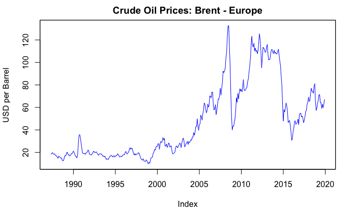

### The plot.xts function

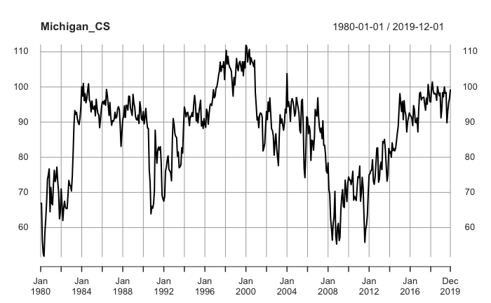

Now let’s creat a summary plot of the `USgas` data. The plot will include:

- The series
- a moving average of the series
- the monthly percentage change of the series
- the year-over-year percentage growth of each observation of the series

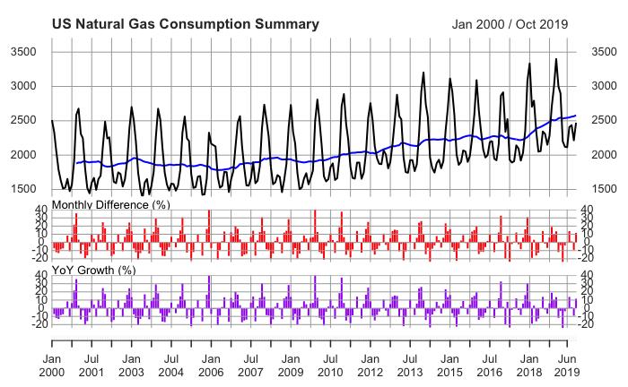

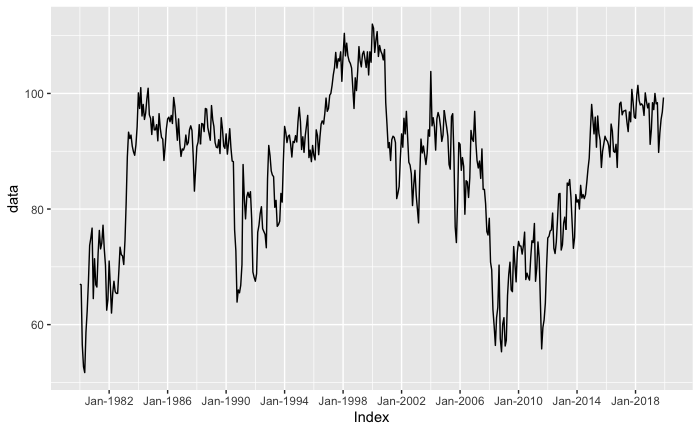